# Computational Techniques Assignment 8

Adeline Makokha - 191199

2025-05-12

## Question 1: Hospital Department Efficiency

You are analyzing the performance of 4 hospital departments. Each department has a different combination of medical staff and beds.

**Objective:**  
Determine which department is most efficient in treating patients with limited resources.

**Inputs:** - Doctors: 40, 35, 45, 38  
- Nurses: 80, 70, 85, 75  
- Beds: 150, 140, 160, 145

**Outputs:** - Patients treated: 2000, 1900, 2100, 1950  
- Survival rate: 0.97, 0.96, 0.98, 0.95

```r
library(Benchmarking)
# Read hospital data

hospital_data <- read.csv("C:/Users/PC/Downloads/ADEH-MSC/Module 3/Module-3/DSA 8302 Computational Techniques in DS/week 8/hospital_data.csv")
```

```r
# Print raw data
print("Hospital Department Data:")
```

```
## [1] "Hospital Department Data:"
```

```r
print(hospital_data)
```

```
##      DMU Doctors Nurses Beds Patients SurvivalRate
## 1 Dept A      40     80  150     2000         0.97
## 2 Dept B      35     70  140     1900         0.96
## 3 Dept C      45     85  160     2100         0.98
## 4 Dept D      38     75  145     1950         0.95
```

```r
# Prepare input and output matrices
inputs <- as.matrix(hospital_data[, c("Doctors", "Nurses", "Beds")])
outputs <- as.matrix(hospital_data[, c("Patients", "SurvivalRate")])

# DEA using CCR model (constant returns to scale), input-oriented
dea_ccr <- dea(X = inputs, Y = outputs, RTS = "crs", ORIENTATION = "in")
hospital_data$CCR_Efficiency <- dea_ccr$eff

# DEA using BCC model (variable returns to scale), input-oriented
dea_bcc <- dea(X = inputs, Y = outputs, RTS = "vrs", ORIENTATION = "in")
hospital_data$BCC_Efficiency <- dea_bcc$eff

# Print efficiency results
print("DEA Efficiency Scores (CCR and BCC):")
```

```
## [1] "DEA Efficiency Scores (CCR and BCC):"
```

```r
print(hospital_data[, c("DMU", "CCR_Efficiency", "BCC_Efficiency")])
```

```
##      DMU CCR_Efficiency BCC_Efficiency
## 1 Dept A      0.9824561              1
## 2 Dept B      1.0000000              1
## 3 Dept C      0.9671053              1
## 4 Dept D      0.9909256              1
```

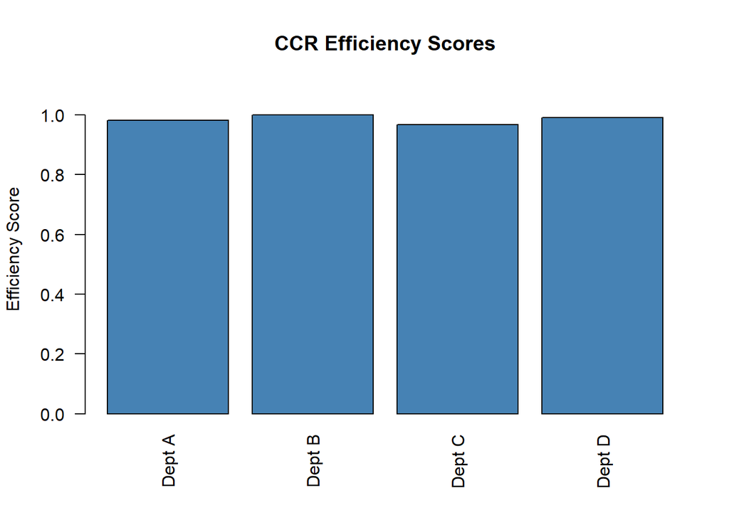

```r
# Plot CCR Efficiency
barplot(hospital_data$CCR_Efficiency, names.arg=hospital_data$DMU,
        col="steelblue", ylim=c(0,1.1), main="CCR Efficiency Scores",
        ylab="Efficiency Score", las=2)
```

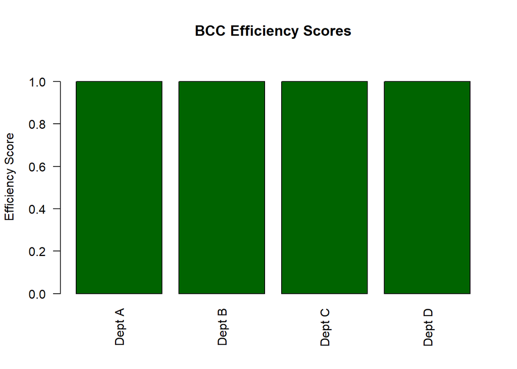

```r
# Plot BCC Efficiency
barplot(hospital_data$BCC_Efficiency, names.arg=hospital_data$DMU,
        col="darkgreen", ylim=c(0,1.1), main="BCC Efficiency Scores",
        ylab="Efficiency Score", las=2)
```

## Question 2: Retail Store Efficiency

A retail company wants to assess whether its 4 branches are efficiently turning staff and marketing investment into profit.

**Objective:**  
Identify the best performing store branch given similar resource levels.

**Inputs:** - Marketing Spend (USD): 12,000; 10,000; 11,500; 9,800  
- Employees: 20, 18, 22, 19

**Outputs:** - Monthly Revenue (USD): 110,000; 100,000; 120,000; 95,000  
- Number of Customers: 2,300; 2,000; 2,600; 1,900

```r
# Read retail data

retail_data <- read.csv("C:/Users/PC/Downloads/ADEH-MSC/Module 3/Module-3/DSA 8302 Computational Techniques in DS/week 8/retail_data.csv")

# Print raw data
print("Retail Store Data:")
```

```
## [1] "Retail Store Data:"
```

```r
print(retail_data)
```

```
##       DMU MarketingSpend Employees Revenue Customers
## 1 Store A          12000        20  110000      2300
## 2 Store B          10000        18  100000      2000
## 3 Store C          11500        22  120000      2600
## 4 Store D           9800        19   95000      1900
```

```r
# Prepare input and output matrices
inputs <- as.matrix(retail_data[, c("MarketingSpend", "Employees")])
outputs <- as.matrix(retail_data[, c("Revenue", "Customers")])

# DEA using CCR model (constant returns to scale), input-oriented
dea_ccr <- dea(X = inputs, Y = outputs, RTS = "crs", ORIENTATION = "in")
retail_data$CCR_Efficiency <- dea_ccr$eff

# DEA using BCC model (variable returns to scale), input-oriented
dea_bcc <- dea(X = inputs, Y = outputs, RTS = "vrs", ORIENTATION = "in")
retail_data$BCC_Efficiency <- dea_bcc$eff

# Print efficiency results
print("DEA Efficiency Scores (CCR and BCC):")
```

```
## [1] "DEA Efficiency Scores (CCR and BCC):"
```

```r
print(retail_data[, c("DMU", "CCR_Efficiency", "BCC_Efficiency")])
```

```
##       DMU CCR_Efficiency BCC_Efficiency
## 1 Store A      1.0000000              1
## 2 Store B      1.0000000              1
## 3 Store C      1.0000000              1
## 4 Store D      0.9289966              1
```

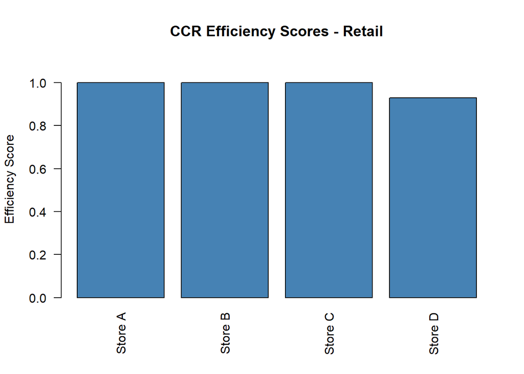

```r
# Plot CCR Efficiency
barplot(retail_data$CCR_Efficiency, names.arg=retail_data$DMU,
        col="steelblue", ylim=c(0,1.1), main="CCR Efficiency Scores - Retail",
        ylab="Efficiency Score", las=2)
```

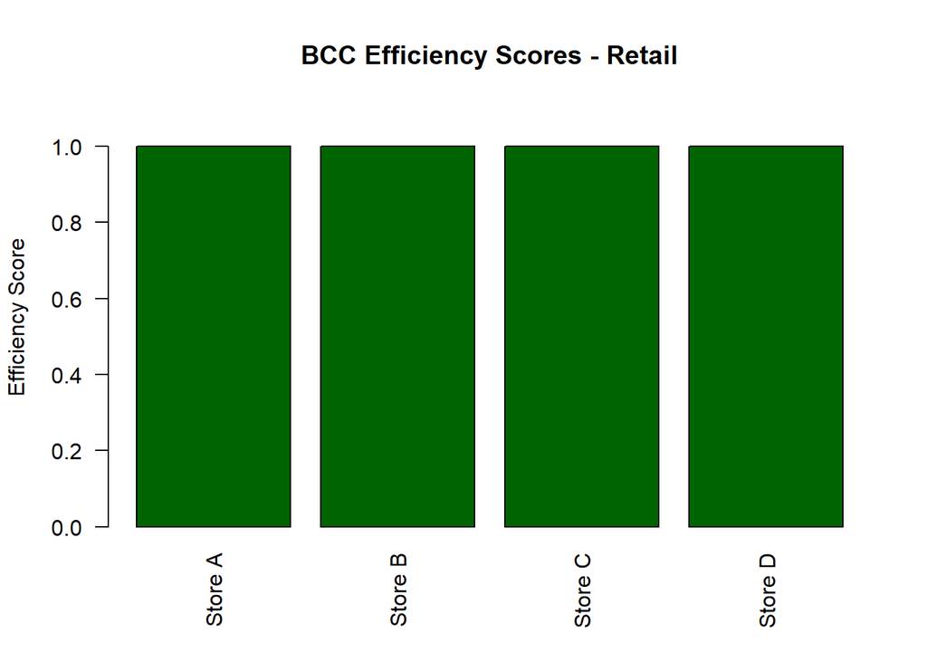

```r
# Plot BCC Efficiency
barplot(retail_data$BCC_Efficiency, names.arg=retail_data$DMU,
        col="darkgreen", ylim=c(0,1.1), main="BCC Efficiency Scores - Retail",
        ylab="Efficiency Score", las=2)
```

## Question 3: School Performance Evaluation

A school district monitors 4 schools to determine which is using its resources most efficiently to produce better academic results.

**Inputs:** - Teachers: 30, 25, 20, 28  
- Annual Budget (USD): 800,000; 750,000; 700,000; 770,000

**Outputs:** - Graduation Rate (%): 85, 90, 82, 88  
- Average Test Score (out of 100): 78, 80, 76, 79

```r
# Read school data

school_data <- read.csv("C:/Users/PC/Downloads/ADEH-MSC/Module 3/Module-3/DSA 8302 Computational Techniques in DS/week 8/school_data.csv")

# Print raw data
print("School Performance Data:")
```

```
## [1] "School Performance Data:"
```

```r
print(school_data)
```

```
##        DMU Teachers Budget GraduationRate TestScore
## 1 School A       30 800000             85        78
## 2 School B       25 750000             90        80
## 3 School C       20 700000             82        76
## 4 School D       28 770000             88        79
```

```r
# Prepare input and output matrices
inputs <- as.matrix(school_data[, c("Teachers", "Budget")])
outputs <- as.matrix(school_data[, c("GraduationRate", "TestScore")])

# DEA using CCR model (constant returns to scale), input-oriented
dea_ccr <- dea(X = inputs, Y = outputs, RTS = "crs", ORIENTATION = "in")
school_data$CCR_Efficiency <- dea_ccr$eff

# DEA using BCC model (variable returns to scale), input-oriented
dea_bcc <- dea(X = inputs, Y = outputs, RTS = "vrs", ORIENTATION = "in")
school_data$BCC_Efficiency <- dea_bcc$eff

# Print efficiency results
print("DEA Efficiency Scores (CCR and BCC):")
```

```
## [1] "DEA Efficiency Scores (CCR and BCC):"
```

```r
print(school_data[, c("DMU", "CCR_Efficiency", "BCC_Efficiency")])
```

```
##        DMU CCR_Efficiency BCC_Efficiency
## 1 School A      0.9017857      0.9062500
## 2 School B      1.0000000      1.0000000
## 3 School C      1.0000000      1.0000000
## 4 School D      0.9577922      0.9577922
```

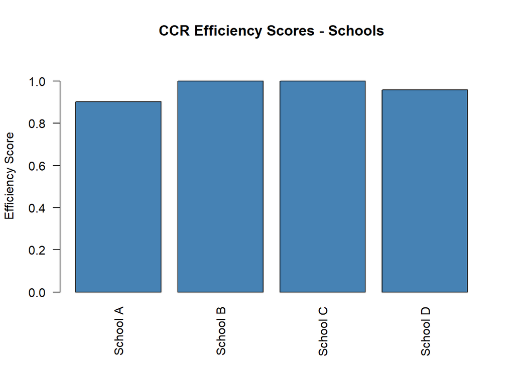

```r
# Plot CCR Efficiency
barplot(school_data$CCR_Efficiency, names.arg=school_data$DMU,
        col="steelblue", ylim=c(0,1.1), main="CCR Efficiency Scores - Schools",
        ylab="Efficiency Score", las=2)
```

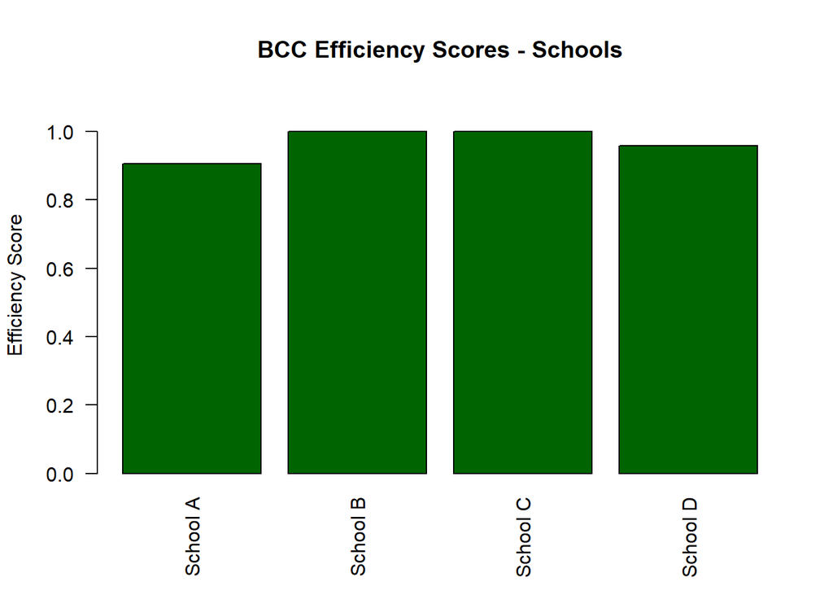

```r
# Plot BCC Efficiency
barplot(school_data$BCC_Efficiency, names.arg=school_data$DMU,
        col="darkgreen", ylim=c(0,1.1), main="BCC Efficiency Scores - Schools",
        ylab="Efficiency Score", las=2)
```